# Top 100 Billboard Music

Jo Hardin

9/14/2021

## The Data

The data this week comes from [Data.World](https://data.world/kcmillersean/billboard-hot-100-1958-2017#) by way of Sean Miller, [Billboard.com](http://billboard.com/) and Spotify.

```r
billboard <- read_csv("billboard.csv")
audio_features <- read_csv("audio_features.csv")
```

```r
billboard %>%
  select(song_id) %>%
  distinct() %>%
  count()
```

```
## # A tibble: 1 × 1
##       n
##   <int>
## 1 29389
```

## Finding the songs of interest

First, we want to `filter` the rows to keep only the songs of interest. We keep the songs that are on the Billboard Top 100 Chart for at least 20 weeks total.

```r
songs <- billboard %>%
  group_by(song_id) %>%
  arrange(desc(week_id)) %>%
  slice(1) %>%
  ungroup %>%
  filter(weeks_on_chart >= 20)
```

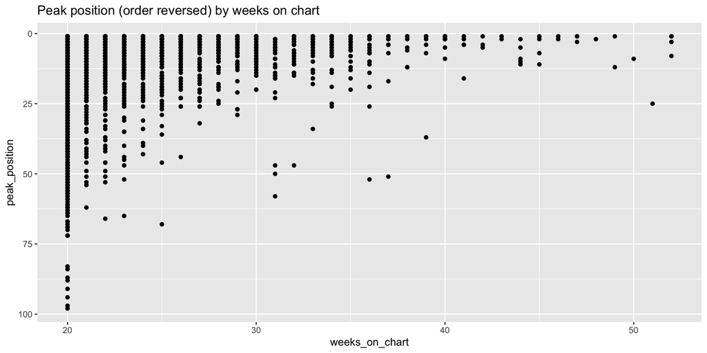

```r
songs %>%
  ggplot() +
  geom_point(aes(x = weeks_on_chart, y = peak_position)) +
  scale_y_continuous(trans = "reverse") +
  ggtitle("Peak position (order reversed) by weeks on chart")
```

Using the top songs, we’ll `join` with the `audio_features` dataset to add features which we can then model to predict genre.

Note: when we do a `left_join` there should be the same number of rows in the output dataframe as in the left dataframe (here `songs`). In our `left_join` we got **more** rows. Yikes!

```r
songs_full <- songs %>% left_join(audio_features, by = "song_id")
```

```r
# thanks to @nrennie at
# https://github.com/nrennie/tidytuesday/blob/main/2021/14-09-2021/14092021.R
# function for genre
select_genre <- function(word){
  if (is.na(word)){
    return(NA)
  }
  if (grepl("pop", word, fixed = TRUE)){
    return("Pop")
  }
  if (grepl("rap", word, fixed = TRUE)){
    return("Rap")
  }
  if (grepl("rock", word, fixed = TRUE)){
    return("Rock")
  }
  if (grepl("country", word, fixed = TRUE)){
    return("Country")
  }
  if (grepl("r&b", word, fixed = TRUE)){
    return("R & B")
  }
  if (grepl("hip hop", word, fixed = TRUE)){
    return("Hip Hop")
  }
  else {
    return("Other")
  }
}
```

```r
main_genre = sapply(songs_full$spotify_genre, function(x) unlist(strsplit(str_sub(x, 3, -3), split = "\', \'"))[1])
songs_full$main_genre <- main_genre
genre <- unname(sapply(songs_full$main_genre, function(x) select_genre(x)))
songs_full$genre <- genre
```

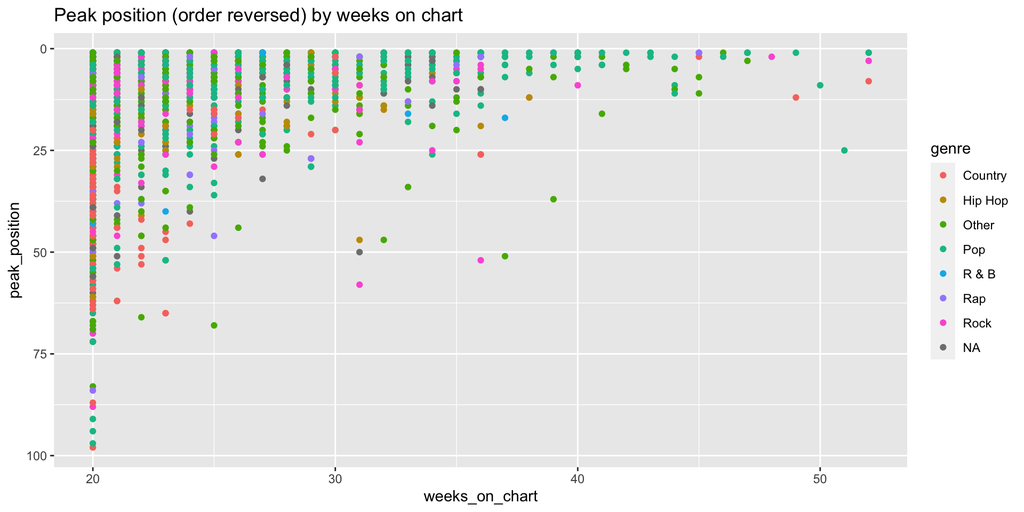

```r
songs_full %>%
  ggplot() +
  geom_point(aes(x = weeks_on_chart, y = peak_position, color = genre)) +
  scale_y_continuous(trans = "reverse") +
  ggtitle("Peak position (order reversed) by weeks on chart")
```

```r
songs_full %>%
  select(genre, main_genre, spotify_genre)
```

```
## # A tibble: 1,927 × 3
##    genre   main_genre       spotify_genre
##    <chr>   <chr>            <chr>
##  1 Pop     dance pop        ['dance pop', 'pop', 'post-teen pop']
##  2 Hip Hop east coast hip … ['east coast hip hop', 'hip hop', 'pop rap', 'rap',…
##  3 <NA>    <NA>             []
##  4 Pop     dance pop        ['dance pop', 'hip hop', 'pop', 'pop rap', 'rap', '…
##  5 Other   adult standards  ['adult standards', 'contemporary vocal jazz', 'lou…
##  6 Rap     new jersey rap   ['new jersey rap']
##  7 Country contemporary co… ['contemporary country', 'country', 'country dawn',…
##  8 Other   adult standards  ['adult standards', 'bubblegum pop', 'country rock'…
##  9 Pop     dance pop        ['dance pop', 'hip hop', 'pop', 'pop rap', 'rap', '…
## 10 Pop     dance pop        ['dance pop', 'hip pop', 'pop', 'pop rap', 'post-te…
## # … with 1,917 more rows
```

## Building a k-nn classifier

The goal of the model will be to predict `genre` from:

`danceability`, `energy`, `key`, `loudness`, `mode`, `speechiness`, `acousticness`, `instrumentalness`, `liveness`, `valence`, `tempo`, `spotify_track_popularity`

#### data split

```r
set.seed(4747)
songs_split <- songs_full %>%
  select(song_id, week_id, genre, danceability, energy, key, loudness, mode, speechiness,
         acousticness, instrumentalness, liveness, valence, tempo,
         spotify_track_popularity) %>%
  filter(genre != "R & B") %>%
  drop_na() %>%
  initial_split()

songs_train <- training(songs_split)
songs_test <- testing(songs_split)
```

#### recipe

```r
songs_recipe <- recipe(genre ~., data = songs_train) %>%
  update_role(song_id, new_role = "ID") %>%
  update_role(week_id, new_role = "ID") %>%
  step_normalize(all_predictors())

songs_recipe
```

```
## Data Recipe
##
## Inputs:
##
##       role #variables
##         ID          2
##    outcome          1
##  predictor         12
##
## Operations:
##
## Centering and scaling for all_predictors()
```

#### set a model

```r
songs_mod <- nearest_neighbor(
  neighbors = 7,
  weight_func = "gaussian") %>%
  set_mode("classification") %>%
  set_engine("kknn")
```

#### alternative model setting

if the plan is to tune hyperparameters, then use `tune()` for the parameters:

```r
songs_mod_tune <- nearest_neighbor(
  neighbors = tune(),
  weight_func = "gaussian") %>%
  set_mode("classification") %>%
  set_engine("kknn")
```

#### build workflow

```r
songs_wf1 <- workflow() %>%
  add_recipe(songs_recipe) %>%
  add_model(songs_mod)

songs_wf1
```

```
## ══ Workflow ════════════════════════════════════════════════════════════════════
## Preprocessor: Recipe
## Model: nearest_neighbor()
##
## ── Preprocessor ────────────────────────────────────────────────────────────────
## 0 Recipe Steps
##
## ── Model ───────────────────────────────────────────────────────────────────────
## K-Nearest Neighbor Model Specification (classification)
##
## Main Arguments:
##   neighbors = 7
##   weight_func = gaussian
##
## Computational engine: kknn
```

### fit model

```r
songs_results <- songs_wf1 %>%
  fit(data = songs_train)

songs_results
```

```
## ══ Workflow [trained] ══════════════════════════════════════════════════════════
## Preprocessor: Recipe
## Model: nearest_neighbor()
##
## ── Preprocessor ────────────────────────────────────────────────────────────────
## 0 Recipe Steps
##
## ── Model ───────────────────────────────────────────────────────────────────────
##
## Call:
## kknn::train.kknn(formula = ..y ~ ., data = data, ks = min_rows(7,     data, 5), kernel = ~"gaussian")
##
## Type of response variable: nominal
## Minimal misclassification: 0.6227451
## Best kernel: gaussian
## Best k: 7
```

```r
songs_results %>% predict(new_data = songs_train) %>% cbind(songs_train) %>%
  select(.pred_class, genre) %>% table()
```

```
##            genre
## .pred_class Country Hip Hop Other Pop Rap Rock
##     Country     106       2    22  18   1    6
##     Hip Hop       0      66     2   9   9    1
##     Other         7       3   242  42   4   29
##     Pop          23      40    67 360  22   33
##     R & B         0       0     0   0   0    0
##     Rap           0       1     0   4  21    0
##     Rock          9       1     9  11   0   91
```

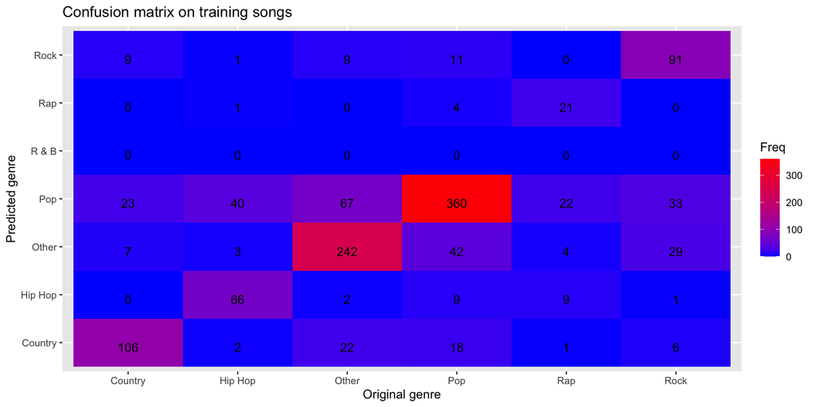

```r
songs_results %>% predict(new_data = songs_train) %>% cbind(songs_train) %>%
  select(.pred_class, genre) %>% table() %>% as.data.frame() %>%
  ggplot(mapping = aes(y = .pred_class,
                     x = genre)) +
  geom_tile(aes(fill = Freq)) +
  geom_text(aes(label = sprintf("%1.0f", Freq)), vjust = 1) +
  scale_fill_gradient(low = "blue",
                      high = "red") +
  ggtitle("Confusion matrix on training songs") +
  labs(y = "Predicted genre",
       x = "Original genre")
```

```r
songs_results %>% predict(new_data = songs_test) %>% cbind(songs_test) %>%
  select(.pred_class, genre) %>% table()
```

```
##            genre
## .pred_class Country Hip Hop Other Pop Rap Rock
##     Country      25       0     8   6   1    3
##     Hip Hop       0      23     4   5   2    0
##     Other         2       4    66  15   2   11
##     Pop           9      11    29 116   6    9
##     R & B         0       0     0   0   0    0
##     Rap           0       2     0   1   9    0
##     Rock          3       0     1   9   0   39
```

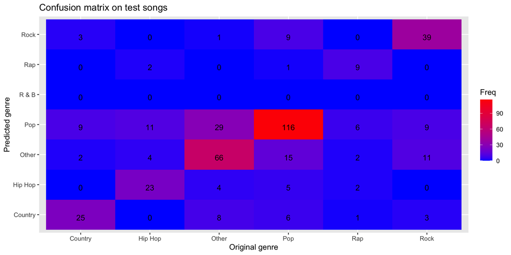

```r
songs_results %>% predict(new_data = songs_test) %>% cbind(songs_test) %>%
  select(.pred_class, genre) %>% table() %>% as.data.frame() %>%
  ggplot(mapping = aes(y = .pred_class,
                     x = genre)) +
  geom_tile(aes(fill = Freq)) +
  geom_text(aes(label = sprintf("%1.0f", Freq)), vjust = 1) +
  scale_fill_gradient(low = "blue",
                      high = "red") +
  ggtitle("Confusion matrix on test songs") +
  labs(y = "Predicted genre",
       x = "Original genre")
```

# Tune the model!

#### build workflow

First, a few extra tidbits we need for finding the best value of `k`.

```r
songs_grid = grid_regular(neighbors(), levels = 5)

set.seed(47)
songs_folds <- vfold_cv(songs_train)
```

```r
songs_wf2 <- workflow() %>%
  add_recipe(songs_recipe) %>%
  add_model(songs_mod_tune)

songs_wf2
```

```
## ══ Workflow ════════════════════════════════════════════════════════════════════
## Preprocessor: Recipe
## Model: nearest_neighbor()
##
## ── Preprocessor ────────────────────────────────────────────────────────────────
## 0 Recipe Steps
##
## ── Model ───────────────────────────────────────────────────────────────────────
## K-Nearest Neighbor Model Specification (classification)
##
## Main Arguments:
##   neighbors = tune()
##   weight_func = gaussian
##
## Computational engine: kknn
```

```r
songs_results2 <- songs_wf2 %>%
  tune_grid(
    resamples = songs_folds,
    grid = songs_grid
  )

songs_results2
```

```
## # Tuning results
## # 10-fold cross-validation
## # A tibble: 10 × 4
##    splits             id     .metrics          .notes
##    <list>             <chr>  <list>            <list>
##  1 <split [1134/127]> Fold01 <tibble [10 × 5]> <tibble [0 × 1]>
##  2 <split [1135/126]> Fold02 <tibble [10 × 5]> <tibble [0 × 1]>
##  3 <split [1135/126]> Fold03 <tibble [10 × 5]> <tibble [0 × 1]>
##  4 <split [1135/126]> Fold04 <tibble [10 × 5]> <tibble [0 × 1]>
##  5 <split [1135/126]> Fold05 <tibble [10 × 5]> <tibble [0 × 1]>
##  6 <split [1135/126]> Fold06 <tibble [10 × 5]> <tibble [0 × 1]>
##  7 <split [1135/126]> Fold07 <tibble [10 × 5]> <tibble [0 × 1]>
##  8 <split [1135/126]> Fold08 <tibble [10 × 5]> <tibble [0 × 1]>
##  9 <split [1135/126]> Fold09 <tibble [10 × 5]> <tibble [0 × 1]>
## 10 <split [1135/126]> Fold10 <tibble [10 × 5]> <tibble [0 × 1]>
```

### collect metrics

```r
songs_results2 %>%
  collect_metrics()
```

```
## # A tibble: 10 × 7
##    neighbors .metric  .estimator  mean     n std_err .config
##        <int> <chr>    <chr>      <dbl> <int>   <dbl> <chr>
##  1         1 accuracy multiclass 0.358    10 0.0148  Preprocessor1_Model1
##  2         1 roc_auc  hand_till  0.595    10 0.0111  Preprocessor1_Model1
##  3         3 accuracy multiclass 0.351    10 0.0170  Preprocessor1_Model2
##  4         3 roc_auc  hand_till  0.663    10 0.0108  Preprocessor1_Model2
##  5         5 accuracy multiclass 0.385    10 0.0146  Preprocessor1_Model3
##  6         5 roc_auc  hand_till  0.704    10 0.0111  Preprocessor1_Model3
##  7         7 accuracy multiclass 0.404    10 0.0142  Preprocessor1_Model4
##  8         7 roc_auc  hand_till  0.726    10 0.00968 Preprocessor1_Model4
##  9        10 accuracy multiclass 0.411    10 0.0123  Preprocessor1_Model5
## 10        10 roc_auc  hand_till  0.739    10 0.00774 Preprocessor1_Model5
```

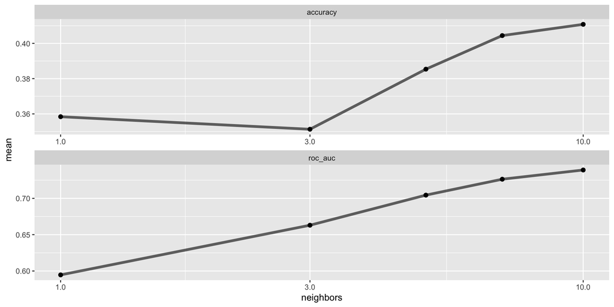

```r
songs_results2 %>%
  collect_metrics() %>%
  ggplot(aes(x = neighbors, y = mean)) +
  geom_line(size = 1.5, alpha = 0.6) +
  geom_point(size = 2) +
  facet_wrap(~ .metric, scales = "free", nrow = 2) +
  scale_x_log10(labels = scales::label_number())
```

```r
songs_results2 %>%
  show_best("roc_auc")
```

```
## # A tibble: 5 × 7
##   neighbors .metric .estimator  mean     n std_err .config
##       <int> <chr>   <chr>      <dbl> <int>   <dbl> <chr>
## 1        10 roc_auc hand_till  0.739    10 0.00774 Preprocessor1_Model5
## 2         7 roc_auc hand_till  0.726    10 0.00968 Preprocessor1_Model4
## 3         5 roc_auc hand_till  0.704    10 0.0111  Preprocessor1_Model3
## 4         3 roc_auc hand_till  0.663    10 0.0108  Preprocessor1_Model2
## 5         1 roc_auc hand_till  0.595    10 0.0111  Preprocessor1_Model1
```

### fit model

```r
songs_best <- songs_results2 %>%
  select_best("accuracy")

songs_best
```

```
## # A tibble: 1 × 2
##   neighbors .config
##       <int> <chr>
## 1        10 Preprocessor1_Model5
```

```r
songs_wf3 <- songs_wf2 %>%
  finalize_workflow(songs_best)

songs_fit3 <- songs_wf3 %>%
  last_fit(songs_split)

songs_fit3 %>%
  collect_metrics
```

```
## # A tibble: 2 × 4
##   .metric  .estimator .estimate .config
##   <chr>    <chr>          <dbl> <chr>
## 1 accuracy multiclass     0.447 Preprocessor1_Model1
## 2 roc_auc  hand_till      0.743 Preprocessor1_Model1
```

Default way to make ROC curve for **each** of the music genres. So cool!!!

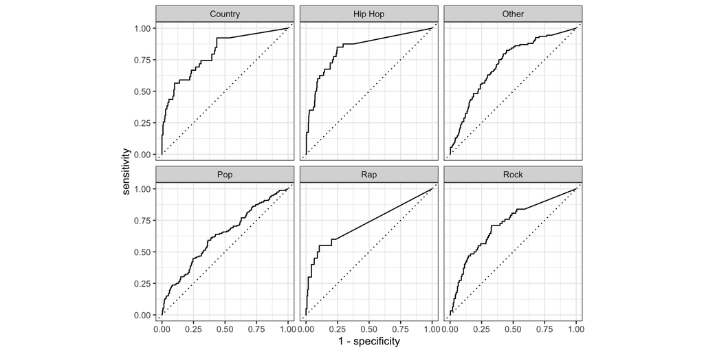

```r
songs_fit3 %>%
  collect_predictions() %>%
  yardstick::roc_curve(genre, .pred_Country:.pred_Rock) %>%
  autoplot()
```

```r
praise()
```

```
## [1] "You are funkadelic!"
```